# Vector Layer

#### Click here for the Raster Tutorial

## Intro

This tutorial is developed to be an exercise that we can use to practice the vector data processing skills delivered in the first part of the workshop. The processing steps covered here include vector data import, conversion, union, clip, and intersect. These steps are basic yet essential in many spatial analyses that you may do on your own. We will also visualize the spatial data using the ggplot2 package and attach labels, heatmap polygon, and other visual components in the final map.

With the spatial analysis tools, we investigate the locations where wolves (*Canis lupus*) in British Columbia and Alberta traverse across or along roads. Despite a higher chance of human-encounter, wolves often move along roads (Moskowitz 2013). We are going to identify locations where such phenomenon occurred most often according to several individuals’ tracks collected in previous studies (Hebblewhite and Merrill 2007; Hebblewhite and Merrill 2008). This information helps minimize the risk of an adverse outcome from wolf-human encounters, for example, by placing road signs at points where wolf activities were frequent.

## Input Data

We are going to work with several spatial datasets, namely wolf tracking data (points), road data (lines), and park boundary data (polygons). These data are available online either to the public with registered accounts (wolf data) or all UBC-affiliated individuals (road and park boundary data: DMTI Spatial Inc. (2014b), DMTI Spatial Inc. (2014a)). For this tutorial, you can access all of the required data from the following [link](https://drive.google.com/file/d/121BoCSOhasXMs6zBzGFAaiNqalNyhjU1/view?usp=sharing).

As the first step, we are going to load the R packages and the data. Please note that you will have to modify the input data commands according to the location of the data in your machine.

```r
# Load relevant libraries
library(sf)                 # spatial vector data manipulation
library(tmap)               # map production & tiled web map
library(ggplot2)            # alternative to tmap for map production
library(ggspatial)          # spatial framework for ggplot2
library(terra)              # gridded spatial data manipulation
library(ggmap)              # download basemap data
library(tmaptools)          # misc. tools in mapping with tmap
library(magick)             # wrapper around ImageMagick STL
library(ggrepel)            # Neatly display labels on our map in ggplot
library(tidyverse)

movementData <- read.csv("E:/pers_plan/ubc/Teaching_assistantship/year_02/BRC/projects/brcSpatial_ws/part2/data/ggplotVisualize/ABoVE_ Hebblewhite Alberta-BC Wolves.csv")
movementData %>% head()
# supporting data 1: road network
BCroadData.spatial <- st_read("E:/pers_plan/ubc/Teaching_assistantship/year_02/BRC/projects/brcSpatial_ws/part2/data/ggplotVisualize/BCrds.shp")
ABroadData.spatial <- st_read("E:/pers_plan/ubc/Teaching_assistantship/year_02/BRC/projects/brcSpatial_ws/part2/data/ggplotVisualize/ABrds.shp")
# supporting data 2: park areas
parkData.spatial <- st_read("E:/pers_plan/ubc/Teaching_assistantship/year_02/BRC/projects/brcSpatial_ws/part2/data/ggplotVisualize/CANprr.shp")
```

We have imported all of the required data now. Apparently, not all of the inputs are vector data. The tracking data is stored as a `data.frame`. We are going to convert the data.frame into an `sf` object using a function `st_as_sf` that takes the `data.frame` as an input. To develop the vector data, we have to provide two arguments: the `columns` containing the X and Y coordinates and the `crs`, i.e. coordinate reference system to let the function know the properties of the coordinates, i.e., datum, unit, etc.

```r
# Creating sf object from the data.frame
movementData.spatial <- movementData %>% st_as_sf(coords = c("location.long", "location.lat"), crs = 4326)

# Checking the consistency of the CRS across data
# Loop for each spatial data
spatialData <- ls(pattern = "spatial$") %>% setdiff("movementData.spatial")  # exclude the movement data as reference
```

After this, at the beginning of our spatial analysis, we should always check the consistency of the coordinate reference system used in all of our data. Based on the assessment, we should decide if CRS conversions are necessary before going forward. In our case, even though all data have the same CRS of WGS84, it is recommended to project the data into BC Albers projection system (see [this link](https://ibis.geog.ubc.ca/~brian/Course.Notes/bceprojection.html)).

```r
crs_check <- lapply(spatialData, function(x){
  eval(substitute(st_crs(movementData.spatial) == st_crs(i), list(i = as.name(x))))
}) %>% unlist()
names(crs_check) <- spatialData
print(crs_check)
```

```
## ABroadData.spatial BCroadData.spatial   parkData.spatial
##               TRUE               TRUE               TRUE
```

```r
# if all TRUE, then we can move on.. Can we?
spatialData <- c(spatialData, "movementData.spatial")
# Project all data, including the movement data into BC Albers Projection (NAD83)
for(s in 1:length(spatialData)){
  eval(parse(text = paste0(spatialData[s], "<- st_transform(", spatialData[s], ", crs = 3005)")))
}

print(crs(movementData.spatial))
```

```
## CRS arguments:
##  +proj=aea +lat_0=45 +lon_0=-126 +lat_1=50 +lat_2=58.5 +x_0=1000000
## +y_0=0 +datum=NAD83 +units=m +no_defs
```

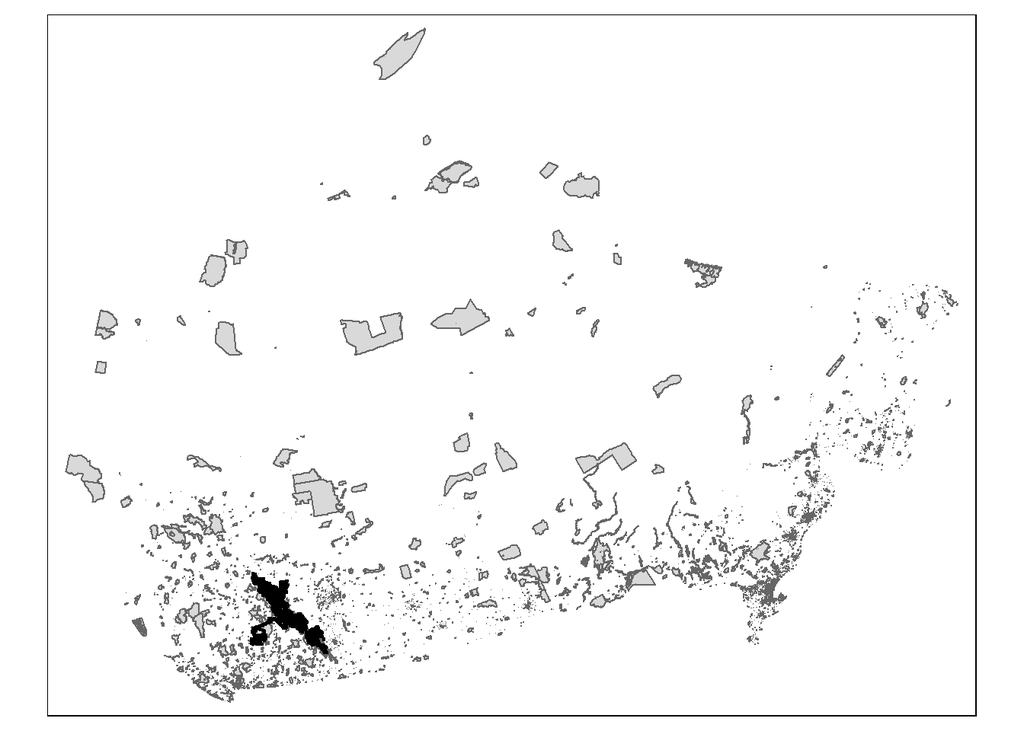

```r
# Simple plotting.. Remember that order matters
tm_shape(parkData.spatial) + tm_polygons() + tm_shape(movementData.spatial) + tm_dots()
```

For more efficient processing, let’s clip the spatial dataset according to the extent of our movement data.

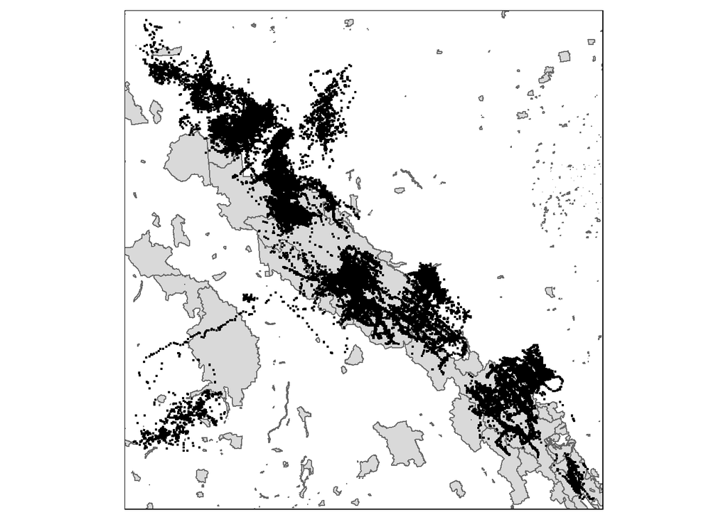

```r
# Plotting using predefined bounding box
# try plotting again
area_bbox <- st_as_sfc(st_bbox(movementData.spatial))
tm_shape(parkData.spatial, bbox = area_bbox) + tm_polygons() + tm_shape(movementData.spatial) + tm_dots()
```

```r
# parks Data
parkData.spatial <- st_intersection(parkData.spatial, area_bbox)
# roads Data
allRoads.spatial <- BCroadData.spatial %>% rbind(ABroadData.spatial) %>% st_intersection(area_bbox) # alternatively, use st_union (slower)
```

## Basic Data Manipulation: Data Type Conversion, and Intersection Identification

We can see that the tracking data are recorded in an interval of some time. We will assume that the tracked individuals move in straight trajectories between the subsequent locations. To apply this assumption in our data, we are converting the movement points into polylines.

With the movement data as lines, we can estimate the locations where wolves were likely to traverse across or along roads even though the recorded locations do not intersect the road segments directly.

```r
movementData.lineString <- movementData.spatial %>% group_by(individual.local.identifier) %>% arrange(event.id, .by_group = TRUE)%>% summarise(do_union = FALSE) %>%  st_cast("LINESTRING")
# intersection of roads and wolf paths
intersectMoveRoad <- st_intersection(movementData.lineString, allRoads.spatial) %>% st_cast("MULTIPOINT")
```

## Basic Data Analysis: Center Point

Some individuals may have different affinities towards moving on roads. Therefore, we may want to put some information about the different individuals tracked on the map. A way to do this is to aggregate each individual’s tracks into a center point, where labels indicating individuals’ ids will be displayed on the map.

```r
movementData.centPoints <- movementData.lineString %>% group_by(individual.local.identifier) %>% st_centroid()
```

## Basic Visualization with ggplot2

We now have all of the ingredients to make the final map! We want to make a map highlighting the locations where wolf activities on roads were the highest based on the tracking data. We will show areas with a high density of intersection points between wolf movement and roads.

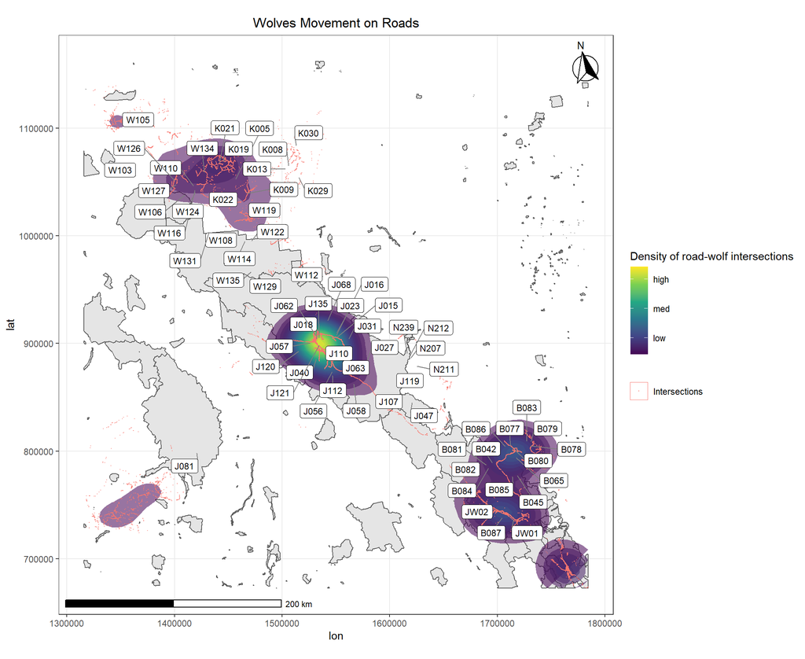

```r
# with ggplot
# requires x and y columns to create the heatmap:
intersect.coords <- intersectMoveRoad %>% st_coordinates() %>% as.data.frame() %>% dplyr::select(-3)
# similar columns required to assign labels appropriately
movementData.centPoints <- movementData.centPoints %>% st_coordinates() %>% as.data.frame() %>% bind_cols(movementData.centPoints)
mapLayout <- ggplot() + geom_sf(data = parkData.spatial) +
  stat_density2d(
    aes(x = X, y = Y, fill = ..level.., alpha = 0.1),
    size = 0.01, bins = 30, data = intersect.coords,
    geom = "polygon"
  )  + scale_fill_continuous(breaks = c(5.0e-11, 1.25e-10, 2.0e-10), labels = c("low", "med", "high"), name = "Density of road-wolf intersections", type = "viridis") +
  geom_sf(aes(alpha = 0.1, colour = "Intersections"), data = intersectMoveRoad, size = 0.1) +
  geom_label_repel(aes(x = X, y = Y, label = individual.local.identifier), data = movementData.centPoints,
                   size = 3,
                   box.padding = 0.2, point.padding = 0.3,
                   segment.color = 'grey50') + coord_sf(datum=st_crs(3005)) + labs(title = "Wolves Movement on Roads", x = "lon", y = "lat") +
  annotation_scale(location = "bl", width_hint = 0.4) +
  annotation_north_arrow(location = "tr", which_north = "true",
                         pad_x = unit(0.1, "in"), pad_y = unit(0.1, "in"),
                         style = north_arrow_fancy_orienteering) + theme_bw() + theme(plot.title = element_text(hjust = 0.5)) + scale_alpha(guide = 'none') + guides(colour=guide_legend(title=NULL, override.aes=list(fill=NA)))

print(mapLayout)
```

## References

DMTI Spatial Inc. 2014a. “CanMap Parks.” Abacus Data Network, V1. https://hdl.handle.net/11272.1/AB2/GRZ0LF.

———. 2014b. “CanMap Streetfiles.” Abacus Data Network, V1. https://hdl.handle.net/11272.1/AB2/RDGJS5.

Hebblewhite, Mark, and Evelyn Merrill. 2008. “Modelling wildlife-human relationships for social species with mixed-effects resource selection models.” *Journal of Applied Ecology* 45 (3): 834–44. https://doi.org/10.1111/j.1365-2664.2008.01466.x.

Hebblewhite, Mark, and Evelyn H. Merrill. 2007. “Multiscale wolf predation risk for elk: Does migration reduce risk?” *Oecologia* 152 (2): 377–87. https://doi.org/10.1007/s00442-007-0661-y.

Moskowitz, David. 2013. *Wolves in the Land of Salmon*. Timber Press.